# Macrofauna Production

Chih-Lin Wei

2023-03-01

```r
library(bbbs)
#library(devtools)
#install_github("HenrikeAndresen/BenthicPro")
library(BenthicPro)
library(ggplot2)
library(plyr)
library(doBy)
library(readxl)
library(knitr)
library(nlme)

large <- theme(legend.title = element_text(size=20),
        legend.text = element_text(size=20),
        axis.title = element_text(size=20),
        axis.text = element_text(size=20))
rotate <- theme(axis.text.x = element_text(size=20, angle=60, hjust=0.5))

# dark theme for ggplot
dark <- theme(plot.background = element_rect(colour = 'NA', fill = 'gray10'),
        panel.background = element_rect(colour = 'NA', fill = 'transparent'),
        legend.background = element_rect(colour = 'NA', fill = 'transparent'),
        legend.title = element_text(colour = 'white', size=20),
        legend.text = element_text(colour = 'white', size=20),
        axis.title = element_text(colour = 'white', size=20),
        axis.text = element_text(colour = 'white', size=20),
        axis.ticks = element_line(colour = 'white'),
        panel.border = element_rect(fill = 'NA', colour = 'white'),
        panel.grid.major = element_line(colour = 'gray30'),
        panel.grid.minor = element_line(colour = 'gray20'))
```

# 1 Data preparation

We coverted the macrofauna individual body mass (in mg weight weight) into energy content [J] using [conversion factors](http://www.thomas-brey.de/science/DBconversion/datafiles/Conversion04.zip) from Brey (2010) and then estimated macrofaunal production to biomass ratio (P/B) and annual secondary production (P) from three continuous parameters (temperature, water depth, body mass) and 17 categorical parameters (5 taxa, 7 lifestyle, 4 environment, and and state of exploitation) using the Artificial Neural Network model (ANN) developed by Brey (2012) and available as R package [BenthicPro](https://rdrr.io/github/HenrikeAndresen/BenthicPro/man/BenthicPB.html). The large nematode production to biomass ratio was estimated using the following equation developed by Schwinghamer et al. (1986): $P/B = 0.073*M^{-0.337}$, where M is individual body mass [kcal].

```r
dat <- subset(mac, Cruise=="OR1_1096"|Cruise=="OR1_1102"|Cruise=="OR1_1114"|Cruise=="OR1_1126"|Cruise=="OR1_1128"|Cruise=="OR1_1132")
dat.sum <- summaryBy(Wt~Habitat+Cruise+Station+Deployment+Tube+Taxon, data=dat, FUN=c(sum, length))
names(dat.sum)[-1:-6] <- c("Wt", "Count")
dat.sum$Sample.area <- mac$Area[match(with(dat.sum, paste(Cruise, Station)), with(mac, paste(Cruise, Station)))]

# Convert the numbers of polychaete specimen (with head) to abundance
pols <- subset(mac, Taxon=="Polychaeta" & (Condition=="FH" | Condition=="C" | Condition=="FHT"))
pola <- summaryBy(Wt~Habitat+Cruise+Station+Deployment+Tube+Taxon, data=pols, FUN=length, var.names="Count", keep.names = T)
keep <- match(with(pola, paste(Cruise, Station, Deployment, Tube, Taxon)), with(dat.sum, paste(Cruise, Station, Deployment, Tube, Taxon)))
dat.sum$Count[keep] <- pola$Count

# Convert the numbers of complete ophiroid specimens to abundance
ophs <- subset(mac, Taxon=="Ophiuroidea" & Condition=="C")
opha <- summaryBy(Wt~Habitat+Cruise+Station+Deployment+Tube+Taxon, data=ophs, FUN=length, var.names="Count", keep.names = T)
keep <- match(with(opha, paste(Cruise, Station, Deployment, Tube, Taxon)), with(dat.sum, paste(Cruise, Station, Deployment, Tube, Taxon)))
dat.sum$Count[keep] <- opha$Count

# Remove Cyclopoida and Calanoida
dat.sum <- subset(dat.sum, !(Taxon=="Cyclopoida"|Taxon=="Calanoida"))

# Match to marofauna production parameters
dat.sum <- cbind(dat.sum, mpr[match(dat.sum$Taxon, mpr$Taxon), c("ConFac_j2mgwm", "ConFac_j2mgc")])
dat.sum$Bodymass <- with(dat.sum, Wt*ConFac_j2mgwm/Count)
dat.sum <- cbind(dat.sum, env[match(with(dat.sum, paste(Cruise, Station)), with(env, paste(Cruise, Station))), c("Temperature", "Depth")])
dat.sum <- cbind(dat.sum, mpr[match(dat.sum$Taxon, mpr$Taxon), c(-1:-3, -21)])

# Calculate P/B ratio
individualPB<-BenthicPB(dat.sum)

# Convert bodymass in J to kcal
# Calculate nematode P/B ratio using Schwinghamer et al. (1986) equation
nemaPB <- 0.073*(dat.sum$Bodymass/4184)^-0.337
individualPB[dat.sum$Taxon == "Nematoda", "annual.PtoB"] <- nemaPB[dat.sum$Taxon == "Nematoda"]

PBresults<-cbind(dat.sum,individualPB)

# annual secondary production in mulligram WM per species and sample per square meter
PBresults$productionW <- with(PBresults, annual.PtoB*Wt/Sample.area)

# annual secondary production in Joule per species and sample per square meter
PBresults$productionJ <- with(PBresults, productionW*ConFac_j2mgwm)

# conversion from Joule to milligram carbon per square meter
PBresults$productionC <- with(PBresults, productionJ/ConFac_j2mgc)

# Average P/B ratio by tube
p2b <- summaryBy(Depth+annual.PtoB+lowerCI+upperCI~Habitat+Cruise+Station+Deployment+Tube, data = PBresults, fun = mean, keep.names = TRUE)

# Summation production by tube
pd <- summaryBy(productionW+productionJ+productionC+Count+Wt~Habitat+Cruise+Station+Deployment+Tube, data = PBresults, fun = sum, keep.names = TRUE)
pd <- cbind(p2b, pd[, -1:-5])

# Remove outlier samples with only 1 individuals
bad <- with(pd, Count <=1 | (Cruise=="OR1_1102" & Station == "GS4") )
dat <- subset(dat, !bad)

se <- function(x) sd(x)/length(x)^0.5
out <- summaryBy(Depth+annual.PtoB+lowerCI+upperCI+productionW+productionJ+productionC~Habitat+Cruise+Station, data = pd, FUN = c(mean, sd, length, se))

out <- out[, c("Habitat", "Cruise", "Station", "Depth.mean", "annual.PtoB.mean", "annual.PtoB.se", "productionW.mean", "productionW.se", "productionJ.mean", "productionJ.se", "productionC.mean", "productionC.se", "Depth.length")]

names(out) <- c("Habitat", "Cruise", "Station", "Depth", "annual.PtoB", "annual.PtoB.se", "productionW", "productionW.se", "productionJ", "productionJ.se", "productionC", "productionC.se", "n")

kable(out)
```

| Habitat | Cruise | Station | Depth | annual.PtoB | annual.PtoB.se | productionW | productionW.se | productionJ | productionJ.se | productionC | productionC.se | n |
| --- | --- | --- | --- | --- | --- | --- | --- | --- | --- | --- | --- | --- |
| Canyon | OR1_1096 | GC1 | 222.000 | 5.708745 | 0.4235639 | 438.09795 | 233.91299 | 3231.8279 | 2140.65648 | 71.431213 | 47.0778583 | 3 |
| Canyon | OR1_1096 | GC2 | 462.000 | 4.028255 | 0.9470880 | 366.58677 | 166.76618 | 1298.4474 | 580.01594 | 28.307634 | 12.7561795 | 3 |
| Canyon | OR1_1096 | GC3 | 655.000 | 3.520696 | 0.1488117 | 369.03309 | 107.61984 | 1300.1040 | 379.14481 | 28.448665 | 8.2963853 | 3 |
| Canyon | OR1_1102 | GC1 | 323.000 | 4.153010 | NA | 250.51328 | NA | 882.5586 | NA | 19.312004 | NA | 1 |
| Canyon | OR1_1102 | GC2 | 482.000 | 4.508543 | 0.5970042 | 48.41773 | 19.80437 | 215.5061 | 48.00701 | 4.965626 | 1.0486657 | 3 |
| Canyon | OR1_1102 | GC3 | 653.000 | 3.230482 | 0.2244218 | 337.16947 | 147.73679 | 1372.9133 | 662.34687 | 31.562487 | 15.1231838 | 3 |
| Canyon | OR1_1102 | GC4 | 1065.200 | 2.713239 | 0.0470124 | 106.00001 | 24.52195 | 783.2160 | 245.00245 | 19.139728 | 6.3775922 | 3 |
| Canyon | OR1_1114 | GC1 | 319.750 | 5.416856 | 0.8805899 | 110.38251 | 33.02680 | 340.6569 | 86.48928 | 7.452750 | 1.8939454 | 5 |
| Canyon | OR1_1114 | GC2 | 478.000 | 4.734681 | 0.4733065 | 191.78231 | 25.80382 | 747.4467 | 108.28631 | 16.629643 | 2.5042251 | 4 |
| Canyon | OR1_1114 | GC3 | 654.750 | 3.400841 | 0.1689784 | 135.89974 | 29.56029 | 934.8586 | 198.15358 | 23.142742 | 4.9892808 | 4 |
| Canyon | OR1_1114 | GC4 | 1051.000 | 2.981240 | 0.2495377 | 592.44836 | 500.67080 | 2219.7269 | 1797.04592 | 49.284136 | 39.5150067 | 6 |
| Canyon | OR1_1126 | GC1 | 318.000 | 4.305008 | 0.3218743 | 61.88684 | 13.83022 | 202.0125 | 37.62676 | 4.420406 | 0.8233427 | 5 |
| Canyon | OR1_1126 | GC3 | 655.000 | 3.118402 | 0.2267129 | 440.14155 | 396.13268 | 1692.2088 | 1332.15220 | 37.876099 | 28.8222680 | 2 |
| Canyon | OR1_1126 | GC4 | 1067.667 | 2.919722 | 0.2087229 | 77.18300 | 19.35275 | 476.0532 | 76.98293 | 11.639235 | 1.8662277 | 4 |
| Slope | OR1_1096 | GS1 | 270.000 | 5.511483 | 0.7938110 | 478.56134 | 213.97408 | 2287.9715 | 1206.59975 | 48.654849 | 26.3668761 | 3 |
| Slope | OR1_1096 | GS2 | 465.000 | 4.923559 | 0.4813619 | 423.13834 | 117.96582 | 1908.4790 | 655.71835 | 42.476905 | 14.0250725 | 3 |
| Slope | OR1_1096 | GS3 | 692.000 | 3.747047 | 0.3335436 | 378.24084 | 86.63886 | 1731.5493 | 770.68596 | 38.530270 | 17.3299161 | 3 |
| Slope | OR1_1102 | GS1 | 278.670 | 5.947975 | 0.1383972 | 4750.94658 | 2693.83837 | 16823.3092 | 9481.08195 | 368.778272 | 207.3397842 | 3 |
| Slope | OR1_1102 | GS2 | 463.540 | 4.995794 | 0.0745870 | 905.64121 | 659.83906 | 3405.7539 | 2447.53612 | 75.875058 | 54.1265289 | 3 |
| Slope | OR1_1102 | GS3 | 682.000 | 3.714523 | 0.4629122 | 202.60867 | 67.80874 | 829.9404 | 257.06092 | 18.585028 | 5.6670597 | 4 |
| Slope | OR1_1114 | GS1 | 279.000 | 5.665107 | 0.0750389 | 1968.26993 | 1264.18347 | 6780.6432 | 3881.30486 | 151.920110 | 88.2477133 | 4 |
| Slope | OR1_1114 | GS2 | 462.000 | 4.481805 | 0.1403873 | 876.53374 | 466.10079 | 3221.7784 | 1666.41886 | 71.499197 | 36.8320115 | 5 |
| Slope | OR1_1114 | GS3 | 690.000 | 4.180077 | 0.2624720 | 283.16305 | 62.95555 | 1215.6322 | 338.29297 | 27.149120 | 7.3989955 | 4 |
| Slope | OR1_1114 | GS4 | 848.000 | 3.713491 | 0.1452237 | 366.96002 | 63.58978 | 1295.9469 | 213.77915 | 28.998788 | 4.5095619 | 4 |
| Slope | OR1_1126 | GS1 | 277.000 | 5.895109 | 0.1264567 | 703.49520 | 114.58929 | 2847.4248 | 521.37936 | 62.776581 | 11.3920316 | 4 |
| Slope | OR1_1126 | GS2 | 463.000 | 4.711604 | 0.1365607 | 370.86709 | 50.92906 | 1357.0403 | 176.29804 | 30.558953 | 3.8536249 | 4 |
| Slope | OR1_1126 | GS3 | 690.000 | 3.839643 | 0.0819599 | 325.06939 | 43.50511 | 1172.8081 | 179.08048 | 26.026364 | 3.9985158 | 4 |
| Slope | OR1_1126 | GS4 | 848.000 | 3.651538 | 0.1123539 | 242.42216 | 58.20890 | 894.7084 | 202.00628 | 20.107049 | 4.5036146 | 4 |

# 2 Production to biomass ratio

## 2.1 Linear regression with depth

```r
splitBy(~Habitat, out) %>% lapply(FUN=function(x)lm(annual.PtoB~Depth, data=x) %>% summary)
```

```
## $Canyon
##
## Call:
## lm(formula = annual.PtoB ~ Depth, data = x)
##
## Residuals:
##      Min       1Q   Median       3Q      Max
## -0.63766 -0.39049 -0.06033  0.33901  0.73082
##
## Coefficients:
##               Estimate Std. Error t value Pr(>|t|)
## (Intercept)  5.6043748  0.3177843  17.636 6.03e-10 ***
## Depth       -0.0028219  0.0004805  -5.873 7.57e-05 ***
## ---
## Signif. codes:  0 '***' 0.001 '**' 0.01 '*' 0.05 '.' 0.1 ' ' 1
##
## Residual standard error: 0.4984 on 12 degrees of freedom
## Multiple R-squared:  0.7419, Adjusted R-squared:  0.7204
## F-statistic: 34.49 on 1 and 12 DF,  p-value: 7.566e-05
##
##
## $Slope
##
## Call:
## lm(formula = annual.PtoB ~ Depth, data = x)
##
## Residuals:
##      Min       1Q   Median       3Q      Max
## -0.42224 -0.18453  0.03824  0.23503  0.32680
##
## Coefficients:
##              Estimate Std. Error t value Pr(>|t|)
## (Intercept)  6.711243   0.195556   34.32 2.39e-13 ***
## Depth       -0.003912   0.000345  -11.34 9.07e-08 ***
## ---
## Signif. codes:  0 '***' 0.001 '**' 0.01 '*' 0.05 '.' 0.1 ' ' 1
##
## Residual standard error: 0.2624 on 12 degrees of freedom
## Multiple R-squared:  0.9146, Adjusted R-squared:  0.9075
## F-statistic: 128.6 on 1 and 12 DF,  p-value: 9.071e-08
```

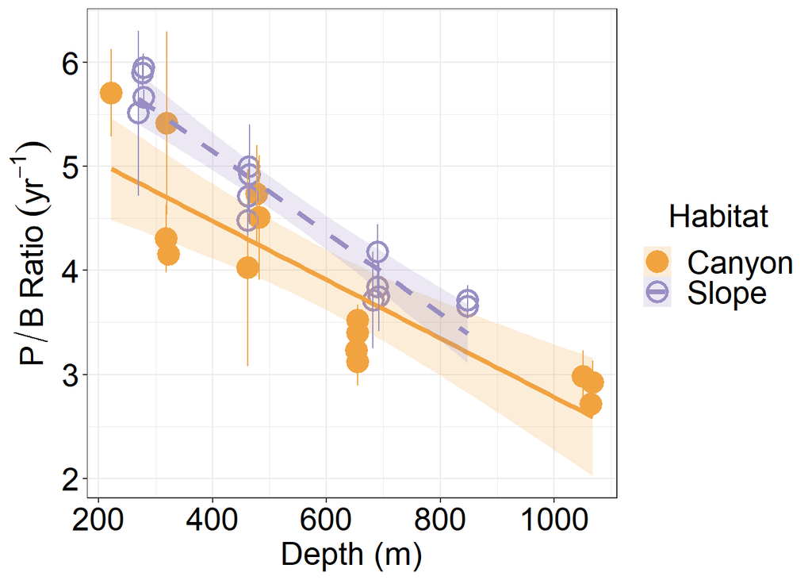

```r
(f4b <- ggplot(data=out,
       aes(x=Depth, y=annual.PtoB,
           ymin=annual.PtoB-annual.PtoB.se, ymax=annual.PtoB+annual.PtoB.se,
           shape=Habitat, colour=Habitat, fill=Habitat, linetype=Habitat))+
  geom_point(size=5, stroke=1.5, position="jitter")+
  stat_smooth(method="lm", formula=y~x, alpha=0.2, size=1.5)+
  geom_errorbar(linetype=1)+
  scale_colour_manual(values=c("#f1a340", "#998ec3"))+
  scale_fill_manual(values=c("#f1a340", "#998ec3"))+
  scale_linetype_manual(values=c(1,2))+
  scale_shape_manual(values=c(19,1))+
  labs(x="Depth (m)", y=expression(P/B~Ratio~(yr^-1)))+
  theme_bw() %+replace% large #%+replace% dark
)
```

```r
save(f4b, file="../rds/f4b.rds")
```

## 2.2 Generalized Least Squares (GLS) modeling

#### 2.2.0.1 Main test

```r
f <- gls(annual.PtoB ~ Habitat+Depth+Cruise+Habitat:Depth+Habitat:Cruise+Depth:Cruise, data=out, method = "REML")
kable(summary(f)$tTable)
```

|  | Value | Std.Error | t-value | p-value |
| --- | --- | --- | --- | --- |
| (Intercept) | 6.2583666 | 0.5197015 | 12.0422325 | 0.0000000 |
| HabitatSlope | 0.9778385 | 0.4745693 | 2.0604756 | 0.0571383 |
| Depth | -0.0041205 | 0.0010325 | -3.9910033 | 0.0011807 |
| CruiseOR1_1102 | -0.8868432 | 0.6860859 | -1.2926125 | 0.2157024 |
| CruiseOR1_1114 | -0.3577422 | 0.6553015 | -0.5459200 | 0.5931480 |
| CruiseOR1_1126 | -1.3153835 | 0.6895290 | -1.9076552 | 0.0757676 |
| HabitatSlope:Depth | -0.0011538 | 0.0007153 | -1.6129839 | 0.1275839 |
| HabitatSlope:CruiseOR1_1102 | 0.3791179 | 0.4788441 | 0.7917355 | 0.4408562 |
| HabitatSlope:CruiseOR1_1114 | -0.1022029 | 0.4611623 | -0.2216202 | 0.8275984 |
| HabitatSlope:CruiseOR1_1126 | 0.5126399 | 0.4834592 | 1.0603581 | 0.3057578 |
| Depth:CruiseOR1_1102 | 0.0013935 | 0.0011961 | 1.1650300 | 0.2622005 |
| Depth:CruiseOR1_1114 | 0.0012969 | 0.0011432 | 1.1345275 | 0.2743790 |
| Depth:CruiseOR1_1126 | 0.0019223 | 0.0011473 | 1.6755214 | 0.1145461 |

```r
kable(anova(f))
```

|  | numDF | F-value | p-value |
| --- | --- | --- | --- |
| (Intercept) | 1 | 2955.3407111 | 0.0000000 |
| Habitat | 1 | 21.6173914 | 0.0003146 |
| Depth | 1 | 97.9747050 | 0.0000001 |
| Cruise | 3 | 0.5116761 | 0.6803158 |
| Habitat:Depth | 1 | 2.8187343 | 0.1138741 |
| Habitat:Cruise | 3 | 0.7941899 | 0.5159604 |
| Depth:Cruise | 3 | 0.9406925 | 0.4456138 |

Significant habitat and depth effects.

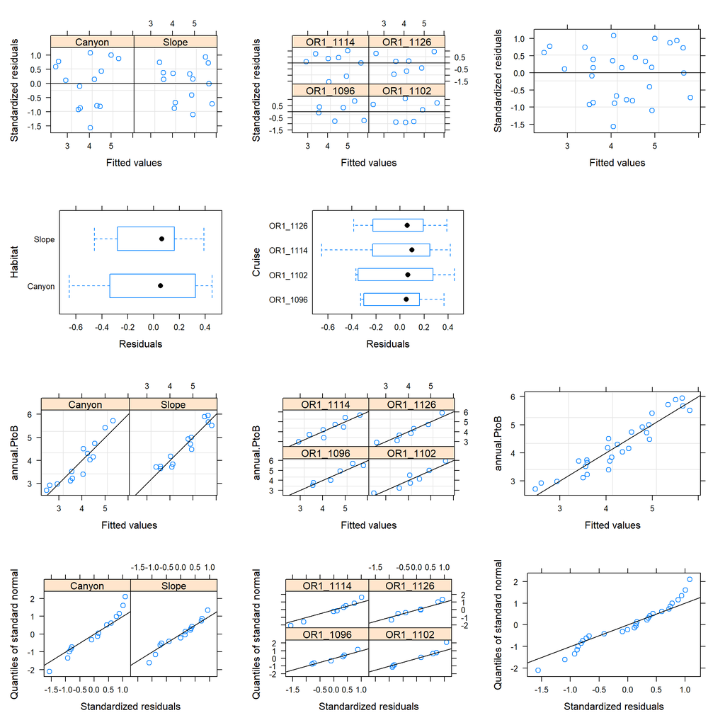

```r
# Function to plot dianotics plot
dianostic_plot <-
  function(f, y){
    # standardized residuals versus fitted values
    a1 <- plot(f, resid(., type = "p") ~ fitted(.) | Habitat, abline = 0)
    a2 <- plot(f, resid(., type = "p") ~ fitted(.) | Cruise, abline = 0)
    a3 <- plot(f, resid(., type = "p") ~ fitted(.), abline = 0)
    # box-plots of residuals
    b1<-plot(f, Habitat ~ resid(.))
    b2 <- plot(f, Cruise ~ resid(.))
    # observed versus fitted values
    c1<-plot(f, paste(paste(y, "fitted(.)", sep="~"), "Habitat", sep="|") %>% formula, abline = c(0,1))
    c2<-plot(f, paste(paste(y, "fitted(.)", sep="~"), "Cruise", sep="|") %>% formula, abline = c(0,1))
    c3<-plot(f, paste(y, "fitted(.)", sep="~") %>% formula, abline = c(0,1))
    # QQ plot
    d1<-qqnorm(f, ~ resid(., type = "p") | Habitat, abline = c(0,1))
    d2<-qqnorm(f, ~ resid(., type = "p") | Cruise, abline = c(0,1))
    d3<-qqnorm(f, ~ resid(., type = "p"), abline = c(0,1))

    print(a1, split=c(1,1,3,4), more=TRUE)
    print(a2, split=c(2,1,3,4), more=TRUE)
    print(a3, split=c(3,1,3,4), more=TRUE)
    print(b1, split=c(1,2,3,4), more=TRUE)
    print(b2, split=c(2,2,3,4), more=TRUE)
    #
    print(c1, split=c(1,3,3,4), more=TRUE)
    print(c2, split=c(2,3,3,4), more=TRUE)
    print(c3, split=c(3,3,3,4), more=TRUE)
    print(d1, split=c(1,4,3,4), more=TRUE)
    print(d2, split=c(2,4,3,4), more=TRUE)
    print(d3, split=c(3,4,3,4))
    }

dianostic_plot(f, y = "annual.PtoB")
```

# 3 Annual production wet weight per square meter

## 3.1 Linear regression with depth

```r
splitBy(~Habitat, out) %>% lapply(FUN=function(x)lm(log10(productionW)~Depth, data=x) %>% summary)
```

```
## $Canyon
##
## Call:
## lm(formula = log10(productionW) ~ Depth, data = x)
##
## Residuals:
##      Min       1Q   Median       3Q      Max
## -0.59525 -0.26024  0.06255  0.28395  0.47851
##
## Coefficients:
##              Estimate Std. Error t value Pr(>|t|)
## (Intercept) 2.2684966  0.2351942   9.645 5.28e-07 ***
## Depth       0.0000244  0.0003556   0.069    0.946
## ---
## Signif. codes:  0 '***' 0.001 '**' 0.01 '*' 0.05 '.' 0.1 ' ' 1
##
## Residual standard error: 0.3689 on 12 degrees of freedom
## Multiple R-squared:  0.0003922,  Adjusted R-squared:  -0.08291
## F-statistic: 0.004709 on 1 and 12 DF,  p-value: 0.9464
##
##
## $Slope
##
## Call:
## lm(formula = log10(productionW) ~ Depth, data = x)
##
## Residuals:
##      Min       1Q   Median       3Q      Max
## -0.39340 -0.21228  0.00943  0.12686  0.61452
##
## Coefficients:
##               Estimate Std. Error t value Pr(>|t|)
## (Intercept)  3.4183142  0.2032105  16.822 1.04e-09 ***
## Depth       -0.0012777  0.0003585  -3.564  0.00389 **
## ---
## Signif. codes:  0 '***' 0.001 '**' 0.01 '*' 0.05 '.' 0.1 ' ' 1
##
## Residual standard error: 0.2726 on 12 degrees of freedom
## Multiple R-squared:  0.5142, Adjusted R-squared:  0.4737
## F-statistic:  12.7 on 1 and 12 DF,  p-value: 0.003895
```

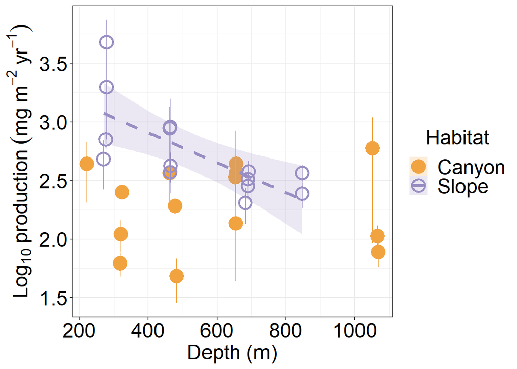

```r
(f4d <- ggplot(data=out,
       aes(x=Depth, y=log10(productionW),
           ymin=log10(productionW-productionW.se), ymax=log10(productionW+productionW.se),
           shape=Habitat, colour=Habitat, fill=Habitat, linetype=Habitat))+
  geom_point(size=5, stroke=1.5, position="jitter")+
  stat_smooth(data=subset(out, Habitat=="Slope"), method="lm", formula=y~x, alpha=0.2, size=1.5)+
  geom_errorbar(linetype=1, position="jitter")+
  scale_colour_manual(values=c("#f1a340", "#998ec3"))+
  scale_fill_manual(values=c("#f1a340", "#998ec3"))+
  scale_linetype_manual(values=c(1,2))+
  scale_shape_manual(values=c(19,1))+
  labs(x="Depth (m)", y=expression(Log[10]~production~(mg~m^-2~yr^-1)))+
  theme_bw() %+replace% large #%+replace% dark
)
```

```r
save(f4d, file="../rds/f4d.rds")
```

Macrofaunal production declined with depth on the slope.

## 3.3 Main test

```r
f <- gls(log10(productionW) ~ Habitat+Depth+Cruise+Habitat:Depth+Habitat:Cruise+Depth:Cruise, data=out, method = "REML")
kable(summary(f)$tTable)
```

|  | Value | Std.Error | t-value | p-value |
| --- | --- | --- | --- | --- |
| (Intercept) | 2.3183135 | 0.3830702 | 6.0519293 | 0.0000222 |
| HabitatSlope | 0.8204141 | 0.3498034 | 2.3453578 | 0.0331761 |
| Depth | 0.0006108 | 0.0007610 | 0.8026178 | 0.4347289 |
| CruiseOR1_1102 | 0.1530326 | 0.5057115 | 0.3026086 | 0.7663440 |
| CruiseOR1_1114 | -0.4331577 | 0.4830204 | -0.8967689 | 0.3840093 |
| CruiseOR1_1126 | -0.4914539 | 0.5082494 | -0.9669543 | 0.3488998 |
| HabitatSlope:Depth | -0.0016844 | 0.0005273 | -3.1945183 | 0.0060312 |
| HabitatSlope:CruiseOR1_1102 | 0.7228947 | 0.3529543 | 2.0481256 | 0.0584720 |
| HabitatSlope:CruiseOR1_1114 | 0.6826562 | 0.3399211 | 2.0082782 | 0.0629715 |
| HabitatSlope:CruiseOR1_1126 | 0.6552221 | 0.3563561 | 1.8386724 | 0.0858449 |
| Depth:CruiseOR1_1102 | -0.0011056 | 0.0008817 | -1.2539729 | 0.2290429 |
| Depth:CruiseOR1_1114 | 0.0000646 | 0.0008426 | 0.0766987 | 0.9398769 |
| Depth:CruiseOR1_1126 | -0.0001981 | 0.0008457 | -0.2342906 | 0.8179272 |

```r
kable(anova(f))
```

|  | numDF | F-value | p-value |
| --- | --- | --- | --- |
| (Intercept) | 1 | 1878.5774458 | 0.0000000 |
| Habitat | 1 | 15.6767744 | 0.0012592 |
| Depth | 1 | 3.2624830 | 0.0909838 |
| Cruise | 3 | 0.7204054 | 0.5552040 |
| Habitat:Depth | 1 | 6.8551853 | 0.0193818 |
| Habitat:Cruise | 3 | 2.0404759 | 0.1514123 |
| Depth:Cruise | 3 | 1.1558854 | 0.3590829 |

Significant habitat effect, but there are also significant interactions between habitat and depth.

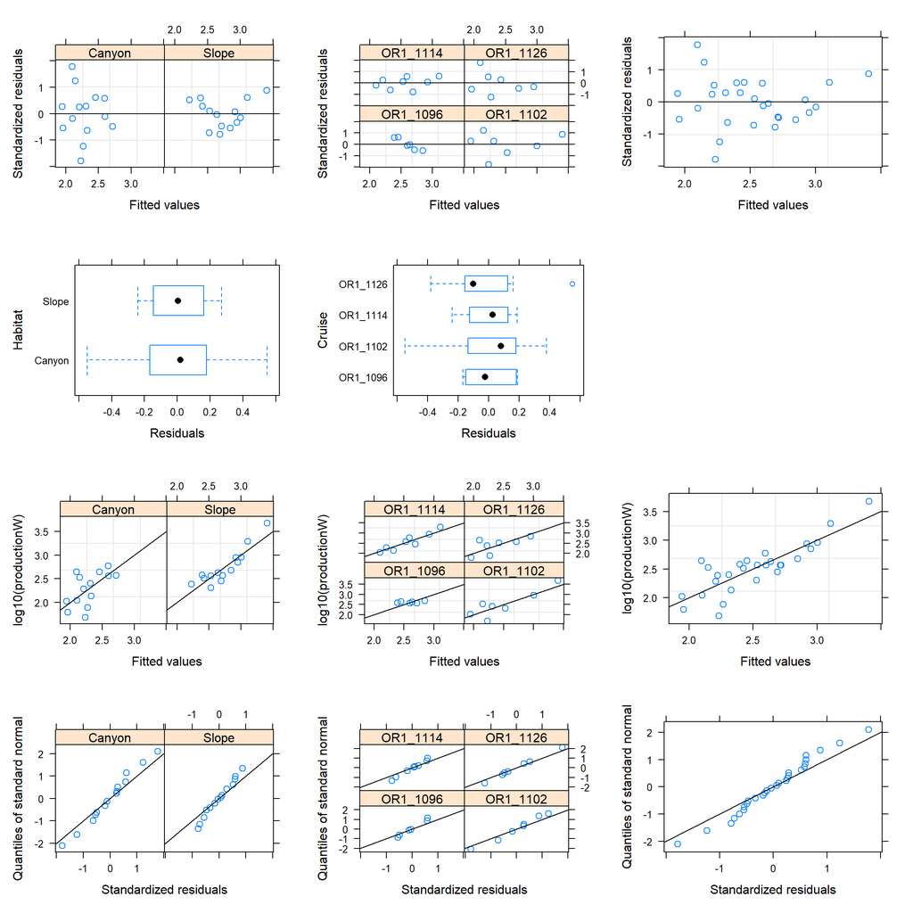

```r
# Dianotics plot
dianostic_plot(f, y = "log10(productionW)")
```

## 3.4 Pairwise tests

```r
# In canyon
f <- gls(log10(productionW) ~ Depth+Cruise+Depth:Cruise, data=subset(out, Habitat == "Canyon"), method = "REML")
kable(summary(f)$tTable)
```

|  | Value | Std.Error | t-value | p-value |
| --- | --- | --- | --- | --- |
| (Intercept) | 2.6704200 | 0.6132285 | 4.3546899 | 0.0047981 |
| Depth | -0.0001781 | 0.0012770 | -0.1394451 | 0.8936614 |
| CruiseOR1_1102 | -0.4015784 | 0.7835513 | -0.5125106 | 0.6266078 |
| CruiseOR1_1114 | -0.9467422 | 0.7853374 | -1.2055228 | 0.2733822 |
| CruiseOR1_1126 | -0.6006675 | 0.8240667 | -0.7289064 | 0.4935166 |
| Depth:CruiseOR1_1102 | 0.0000043 | 0.0014602 | 0.0029718 | 0.9977252 |
| Depth:CruiseOR1_1114 | 0.0011115 | 0.0014654 | 0.7585108 | 0.4768732 |
| Depth:CruiseOR1_1126 | 0.0002337 | 0.0014749 | 0.1584389 | 0.8793091 |

```r
kable(anova(f))
```

|  | numDF | F-value | p-value |
| --- | --- | --- | --- |
| (Intercept) | 1 | 475.4816709 | 0.0000006 |
| Depth | 1 | 0.0041744 | 0.9505835 |
| Cruise | 3 | 1.0657547 | 0.4309101 |
| Depth:Cruise | 3 | 0.4803356 | 0.7078066 |

```r
# On slope
f <- gls(log10(productionW) ~ Depth+Cruise+Depth:Cruise, data=subset(out, Habitat == "Slope"), method = "REML")
kable(summary(f)$tTable)
```

|  | Value | Std.Error | t-value | p-value |
| --- | --- | --- | --- | --- |
| (Intercept) | 2.7428699 | 0.1952241 | 14.0498558 | 0.0000081 |
| Depth | -0.0002414 | 0.0003858 | -0.6255322 | 0.5546532 |
| CruiseOR1_1102 | 1.8439675 | 0.2815263 | 6.5498943 | 0.0006059 |
| CruiseOR1_1114 | 0.8776585 | 0.2536984 | 3.4594559 | 0.0134762 |
| CruiseOR1_1126 | 0.2562239 | 0.2534311 | 1.0110199 | 0.3510267 |
| Depth:CruiseOR1_1102 | -0.0031431 | 0.0005584 | -5.6288155 | 0.0013448 |
| Depth:CruiseOR1_1114 | -0.0011753 | 0.0004685 | -2.5085408 | 0.0459939 |
| Depth:CruiseOR1_1126 | -0.0004976 | 0.0004681 | -1.0629129 | 0.3287180 |

```r
kable(anova(f))
```

|  | numDF | F-value | p-value |
| --- | --- | --- | --- |
| (Intercept) | 1 | 7926.364516 | 0.0000000 |
| Depth | 1 | 71.079986 | 0.0001519 |
| Cruise | 3 | 7.430858 | 0.0191268 |
| Depth:Cruise | 3 | 12.952569 | 0.0049647 |

```r
# GC1 and GS1
f <- gls(log10(productionW) ~ Habitat, data=subset(out, Station=="GC1"|Station=="GS1"), method = "REML")
kable(summary(f)$tTable)
```

|  | Value | Std.Error | t-value | p-value |
| --- | --- | --- | --- | --- |
| (Intercept) | 2.2187251 | 0.2074506 | 10.695198 | 0.0000394 |
| HabitatSlope | 0.9057908 | 0.2933794 | 3.087438 | 0.0214580 |

```r
kable(anova(f))
```

|  | numDF | F-value | p-value |
| --- | --- | --- | --- |
| (Intercept) | 1 | 331.703574 | 0.0000018 |
| Habitat | 1 | 9.532271 | 0.0214580 |

```r
# GC2 and GS2
f <- gls(log10(productionW) ~ Habitat, data=subset(out, Station=="GC2"|Station=="GS2"), method = "REML")
kable(summary(f)$tTable)
```

|  | Value | Std.Error | t-value | p-value |
| --- | --- | --- | --- | --- |
| (Intercept) | 2.1773299 | 0.1877611 | 11.596279 | 0.0000837 |
| HabitatSlope | 0.5965265 | 0.2483846 | 2.401625 | 0.0614972 |

```r
kable(anova(f))
```

|  | numDF | F-value | p-value |
| --- | --- | --- | --- |
| (Intercept) | 1 | 419.7076 | 0.0000051 |
| Habitat | 1 | 5.7678 | 0.0614972 |

```r
# GC3 and GS3
f <- gls(log10(productionW) ~ Habitat, data=subset(out, Station=="GC3"|Station=="GS3"), method = "REML")
kable(summary(f)$tTable)
```

|  | Value | Std.Error | t-value | p-value |
| --- | --- | --- | --- | --- |
| (Intercept) | 2.4679311 | 0.0904704 | 27.2788923 | 0.0000002 |
| HabitatSlope | -0.0058214 | 0.1279444 | -0.0454992 | 0.9651859 |

```r
kable(anova(f))
```

|  | numDF | F-value | p-value |
| --- | --- | --- | --- |
| (Intercept) | 1 | 1484.7674443 | 0.0000000 |
| Habitat | 1 | 0.0020702 | 0.9651859 |

```r
# GC4 and GS4
f <- gls(log10(productionW) ~ Habitat, data=subset(out, Station=="GC4"|Station=="GS4"), method = "REML")
kable(summary(f)$tTable)
```

|  | Value | Std.Error | t-value | p-value |
| --- | --- | --- | --- | --- |
| (Intercept) | 2.2284927 | 0.2284883 | 9.7532019 | 0.0022900 |
| HabitatSlope | 0.2461028 | 0.3612717 | 0.6812125 | 0.5446087 |

```r
kable(anova(f))
```

|  | numDF | F-value | p-value |
| --- | --- | --- | --- |
| (Intercept) | 1 | 172.8577354 | 0.0009505 |
| Habitat | 1 | 0.4640505 | 0.5446087 |

Significant depth effect on slope

# 4 Annual production carbon per square meter

## 4.1 Linear regression with depth

```r
splitBy(~Habitat, out) %>% lapply(FUN=function(x)lm(log10(productionC)~Depth, data=x) %>% summary)
```

```
## $Canyon
##
## Call:
## lm(formula = log10(productionC) ~ Depth, data = x)
##
## Residuals:
##      Min       1Q   Median       3Q      Max
## -0.57035 -0.27423  0.06863  0.20315  0.66094
##
## Coefficients:
##              Estimate Std. Error t value Pr(>|t|)
## (Intercept) 1.1400927  0.2329559   4.894  0.00037 ***
## Depth       0.0002381  0.0003522   0.676  0.51189
## ---
## Signif. codes:  0 '***' 0.001 '**' 0.01 '*' 0.05 '.' 0.1 ' ' 1
##
## Residual standard error: 0.3654 on 12 degrees of freedom
## Multiple R-squared:  0.03668,    Adjusted R-squared:  -0.0436
## F-statistic: 0.4569 on 1 and 12 DF,  p-value: 0.5119
##
##
## $Slope
##
## Call:
## lm(formula = log10(productionC) ~ Depth, data = x)
##
## Residuals:
##      Min       1Q   Median       3Q      Max
## -0.32559 -0.18846 -0.00777  0.11348  0.56510
##
## Coefficients:
##               Estimate Std. Error t value Pr(>|t|)
## (Intercept)  2.3570584  0.1825586   12.91 2.13e-08 ***
## Depth       -0.0012753  0.0003221   -3.96  0.00189 **
## ---
## Signif. codes:  0 '***' 0.001 '**' 0.01 '*' 0.05 '.' 0.1 ' ' 1
##
## Residual standard error: 0.2449 on 12 degrees of freedom
## Multiple R-squared:  0.5665, Adjusted R-squared:  0.5304
## F-statistic: 15.68 on 1 and 12 DF,  p-value: 0.001894
```

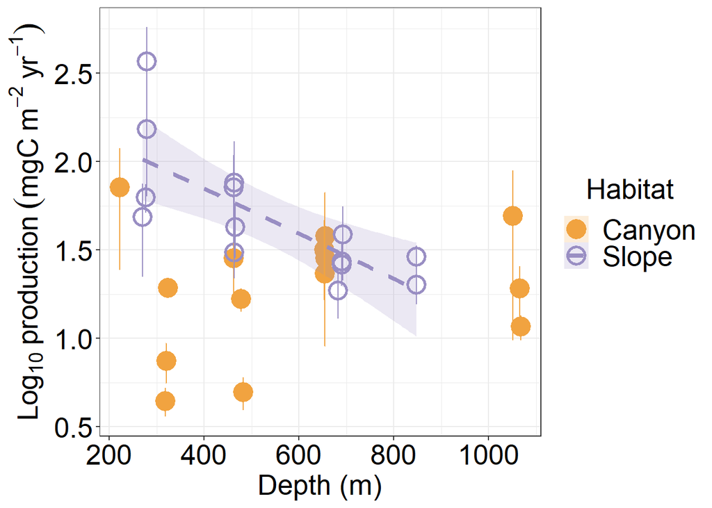

```r
ggplot(data=out,
       aes(x=Depth, y=log10(productionC),
           ymin=log10(productionC-productionC.se), ymax=log10(productionC+productionC.se),
           shape=Habitat, colour=Habitat, fill=Habitat, linetype=Habitat))+
  geom_point(size=5, stroke=1.5, position="jitter")+
  stat_smooth(data=subset(out, Habitat=="Slope"), method="lm", formula=y~x, alpha=0.2, size=1.5)+
  geom_errorbar(linetype=1, position="jitter")+
  scale_colour_manual(values=c("#f1a340", "#998ec3"))+
  scale_fill_manual(values=c("#f1a340", "#998ec3"))+
  scale_linetype_manual(values=c(1,2))+
  scale_shape_manual(values=c(19,1))+
  labs(x="Depth (m)", y=expression(Log[10]~production~(mgC~m^-2~yr^-1)))+
  theme_bw() %+replace% large #%+replace% dark
```

# 5 Annual production J per square meter

## 5.1 Linear regression with depth

```r
splitBy(~Habitat, out) %>% lapply(FUN=function(x)lm(log10(productionJ)~Depth, data=x) %>% summary)
```

```
## $Canyon
##
## Call:
## lm(formula = log10(productionJ) ~ Depth, data = x)
##
## Residuals:
##      Min       1Q   Median       3Q      Max
## -0.57083 -0.28616  0.05262  0.20980  0.65564
##
## Coefficients:
##              Estimate Std. Error t value Pr(>|t|)
## (Intercept) 2.8107085  0.2358792  11.916 5.23e-08 ***
## Depth       0.0001941  0.0003567   0.544    0.596
## ---
## Signif. codes:  0 '***' 0.001 '**' 0.01 '*' 0.05 '.' 0.1 ' ' 1
##
## Residual standard error: 0.3699 on 12 degrees of freedom
## Multiple R-squared:  0.0241, Adjusted R-squared:  -0.05723
## F-statistic: 0.2963 on 1 and 12 DF,  p-value: 0.5962
##
##
## $Slope
##
## Call:
## lm(formula = log10(productionJ) ~ Depth, data = x)
##
## Residuals:
##      Min       1Q   Median       3Q      Max
## -0.31099 -0.18969 -0.00776  0.11268  0.56667
##
## Coefficients:
##              Estimate Std. Error t value Pr(>|t|)
## (Intercept)  4.019137   0.181953  22.089 4.36e-11 ***
## Depth       -0.001291   0.000321  -4.023  0.00169 **
## ---
## Signif. codes:  0 '***' 0.001 '**' 0.01 '*' 0.05 '.' 0.1 ' ' 1
##
## Residual standard error: 0.2441 on 12 degrees of freedom
## Multiple R-squared:  0.5743, Adjusted R-squared:  0.5388
## F-statistic: 16.19 on 1 and 12 DF,  p-value: 0.001689
```

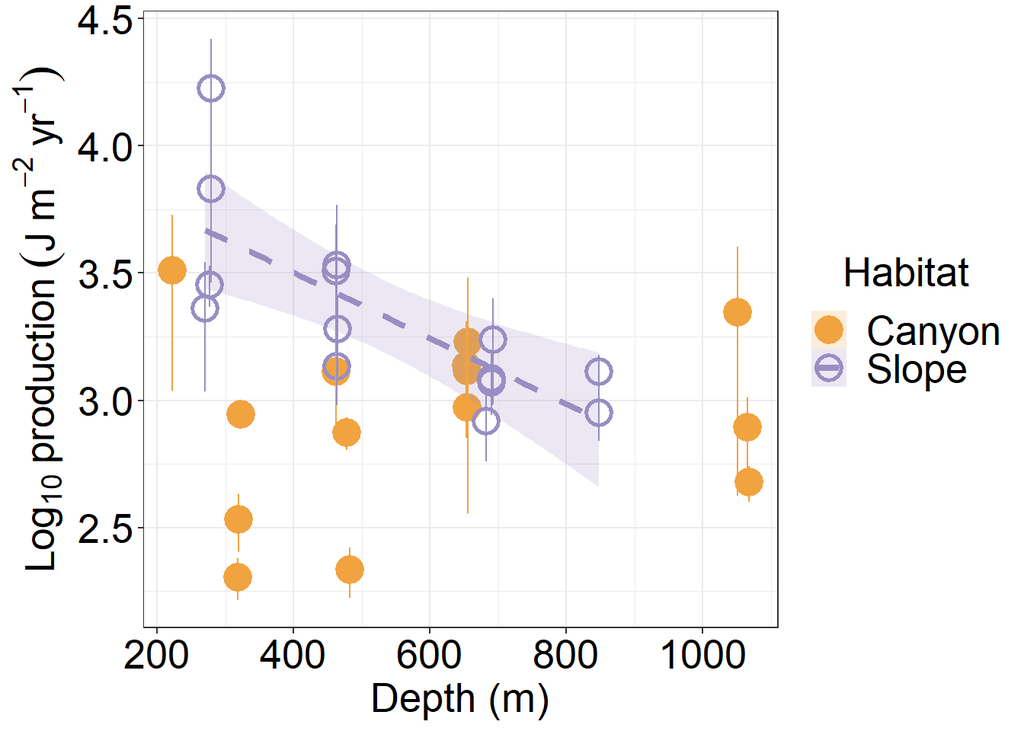

```r
ggplot(data=out,
       aes(x=Depth, y=log10(productionJ),
           ymin=log10(productionJ-productionJ.se), ymax=log10(productionJ+productionJ.se),
           shape=Habitat, colour=Habitat, fill=Habitat, linetype=Habitat))+
  geom_point(size=5, stroke=1.5, position="jitter")+
  stat_smooth(data=subset(out, Habitat=="Slope"), method="lm", formula=y~x, alpha=0.2, size=1.5)+
  geom_errorbar(linetype=1, position="jitter")+
  scale_colour_manual(values=c("#f1a340", "#998ec3"))+
  scale_fill_manual(values=c("#f1a340", "#998ec3"))+
  scale_linetype_manual(values=c(1,2))+
  scale_shape_manual(values=c(19,1))+
  labs(x="Depth (m)", y=expression(Log[10]~production~(J~m^-2~yr^-1)))+
  theme_bw() %+replace% large #%+replace% dark
```